Vamsi Gudipati

Portfolio · Airfoil series · Part 2 of 2 · October 2026

# Eight numbers per flow field: reduced-order models, a β-VAE and a latent-space design search

The same 489 RANS simulations as Part 1, now as whole fields. A linear and a nonlinear reduced model compress each field to eight numbers; a surrogate predicts them from the design parameters and a small head reads lift and drag from them. The chain screens 3,600 candidate airfoils, decodes the field of any design, and stands in for the coefficient surrogate inside the Part 1 control loop.

**Vamsi Gudipati** Reduced-order modelling · Variational autoencoders · Surrogate-based design [Repository](https://github.com/vamsigudipati/airfoil-rom-betavae-design) ← Part 1

40,960 → 8

values per flow field, into eight latent coordinates

0.0557 → 0.0375

test reconstruction error, POD against the β-VAE at the same size (3 seeds)

0.0212 vs 0.0259

C_L RMSE on 111 unseen cases: β-VAE chain against the Part 1 surrogate

2.6 – 4.5×

ensemble spread at the design optima, relative to the grid median

0.0104 vs 0.0095

lift RMSE of PPO trained on the field chain against the surrogate (3 seeds)

## Objective

Part 1 turned 489 RANS simulations into a function of five design numbers that returns lift and drag, and trained a flap controller on it. That function knows nothing about the flow itself. This part asks whether the **whole flow field** can be compressed into a handful of numbers, whether those numbers can be predicted from the design parameters, and what that buys: a design search over thousands of candidate airfoils with a predicted field for each, and a second aerodynamic function for the controller of Part 1, built from the same simulations by a different route.

The work continues the numbering of Part 1:

1. **Stage 5 — Reduced-order models of the flow fields and a latent-space design search.** Two reduced-order models of the fields, a linear one (proper orthogonal decomposition, POD) and a nonlinear one (a β-variational autoencoder, β-VAE), both at eight coordinates per field; a latent surrogate from the five parameters to those coordinates; an aerodynamic head from the coordinates to C_L and C_D; a design search; and the checks on how far the search can be trusted, including an ensemble, an interpretation of the latent space and the cost of a query.
2. **Stage 6 — The field model inside the flap-control loop.** The Stage 5 chain placed in the Part 1 control environment in place of the coefficient surrogate, with PPO trained three times in each environment and every agent tested in both, plus the pressure field decoded along a controlled flight.

## Problem statement

The data are the same 489 four-digit AirfRANS cases as Part 1, but now as fields: for each case, five channels (u/U∞, v/U∞, p/U∞², log(1 + νt/ν) and the signed distance to the surface, negative inside the body) interpolated onto one regular grid of 64 × 128 points covering −0.5 to 1.5 chords in x and −0.5 to 0.5 in y, with the same official split of 378 training and 111 test simulations and the same five parameters per case. A field is 40,960 numbers; the question is how few suffice.

[figure not shown]

**From simulated fields to a design choice.** Stage 1 of the pipeline compresses the fields; stage 2 predicts the compressed coordinates from the design parameters and reads lift and drag from them; stage 3 uses the chain. The dashed box, a solver run to confirm the chosen design, is the step not taken. Green: data; violet: fitted models; blue: physical outputs.

Three questions follow. How few numbers describe a field, and does a nonlinear compression beat a linear one of the same size? Can those numbers be predicted from the design parameters well enough to screen designs by lift and drag? And which admissible four-digit design maximises C_L/C_D at a chosen operating point, and is that answer inside the region the models know? No flow solver is run: every result is a prediction checked against held-out simulations.

## Method

### Two reduced models at the same size

Each channel is standardised with training statistics. **POD** treats each scaled field, flattened to 40,960 values, as one snapshot and keeps the eight orthonormal patterns that carry the most variance; it is the best linear basis of that size, computed as a PCA. The **β-VAE** replaces the fixed patterns with two networks: a convolutional encoder (three stride-2 convolutions, 173,440 weights) that outputs a mean and a log-variance for each of eight coordinates, and a mirrored decoder (116,021 weights). Its loss is the reconstruction error plus β times the Kullback–Leibler term, with β raised linearly to 10⁻³ over the first 30 epochs as a guard against the coordinates collapsing to the prior; 100 epochs, Adam at 10⁻³, batch 32. For evaluation and as the surrogate's target the posterior mean μ is used, never a random sample.

[figure not shown]

**An hourglass: 40,960 values in, eight numbers at the waist, 40,960 out.** Both grid sizes are divisible by 8, so three halvings and three doublings return exactly the input size.

### From parameters to coordinates to forces

A **latent surrogate** (MLP 5 → 64 → 64 → 8, tanh) maps the scaled parameters (with log₁₀ Re) to the eight coordinates, one for POD and one for the β-VAE. An **aerodynamic head** (MLP 8 → 32 → 2, tanh) maps the coordinates to C_L and C_D; it is trained on the coordinates of the true training fields and used on predicted ones, which is the cost measured in question 5. Both are trained with 15 % of the training rows held out for early stopping, latent targets divided by one global scale so the POD coordinates keep their energy ordering, and the head's inputs and targets standardised because C_D is about a hundred times smaller than C_L. Where a result depends on an initialisation, it is repeated with three seeds.

[figure not shown]

**All the expensive work happens once.** The database, the reduced models, the surrogates and the heads are built offline on the 378 training cases; a query then runs two small networks and, if a field is wanted, the decoder.

### Baselines

- POD against the β-VAE at the same size, per channel, on the same 111 unseen fields; POD with 10, 20, 30 and 128 modes for perspective.
- The training-mean coordinates and a linear fit against the latent surrogate, so that the surrogate's share of the error is measured against something.
- A linear head, the mean of the training coefficients, and the Part 1 coefficient surrogate (five parameters straight to C_L, C_D, trained on the same 378 cases) against the aerodynamic head.

## Implementation

What was run, and with what.

[output not shown]

## Results 1 — How many numbers does a field need?

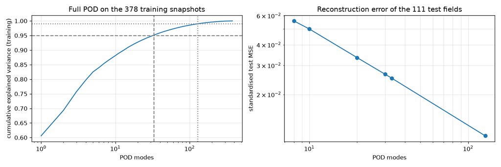

**The variance decays slowly.** 33 POD modes are needed for 95 % of the training variance and 128 for 99 %; the eight used in the project keep 86.4 %. Right: test error against the number of modes, both axes logarithmic.

Test MSE in standardised units on the 111 unseen fields; β-VAE as mean ± std over three seeds.

| Channel | POD-8 | β-VAE-8 |
| --- | --- | --- |
| u/U∞ | 0.0725 | 0.0466 ± 0.0015 |
| v/U∞ | 0.0108 | 0.0148 ± 0.0006 |
| p/U∞² | 0.0374 | 0.0312 ± 0.0011 |
| log(1 + νt/ν) | 0.1565 | 0.0901 ± 0.0073 |
| signed distance | 0.0016 | 0.0046 ± 0.0004 |
| all channels | 0.0557 | 0.0375 ± 0.0022 |

At eight coordinates the nonlinear model wins overall, 0.0375 against 0.0557, and the seed spread (0.0353 to 0.0397) is small next to the gap. It wins on the hard channels (u, pressure, turbulent viscosity) and loses on the two easiest (v and the signed distance), where a linear basis already does well. POD with 20 modes (0.0334) beats the β-VAE with eight, so the β-VAE is justified only because the models downstream need few coordinates.

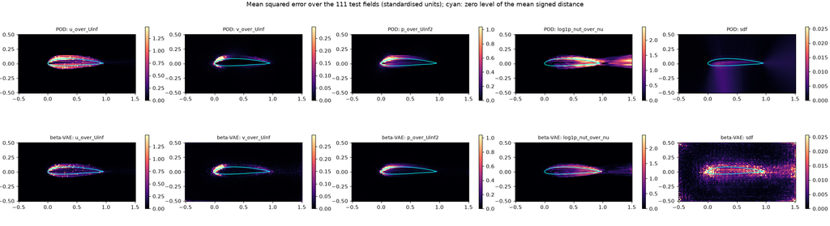

**Where the error lives.** Mean squared error over the 111 test fields per channel, POD above and β-VAE below; cyan is the zero level of the mean signed distance. The error hugs the surface and, for turbulent viscosity, the wake: within 0.02 chord of the surface it is two to three orders of magnitude larger than beyond 0.1 chord. The β-VAE's signed-distance error is spread thinly over the whole domain.

Reduction against prediction. With the MLP almost all of the error is reduction, so a better surrogate cannot help much and a better compression can; the MLP earns its place over the linear fit and the mean.

| Field error (test MSE) | POD | β-VAE |
| --- | --- | --- |
| Reduction error (true coordinates) | 0.0557 | 0.0374 |
| Surrogate error, MLP (3 seeds) | 0.0014 | 0.0013 |
| Total with the MLP | 0.0571 | 0.0380 |
| Total with a linear fit | 0.1155 | 0.0946 |
| Total with the training mean | 0.3883 | 0.4272 |

## Results 2 — Lift and drag from eight numbers

The β-VAE chain over three seeds: C_L RMSE 0.0212 ± 0.0023, C_D RMSE 0.00074 ± 0.00002.

| Model (111 test cases) | C_L MAE | C_L RMSE | C_L R² | C_D MAE | C_D RMSE | C_D R² | Runs |
| --- | --- | --- | --- | --- | --- | --- | --- |
| Mean of the training coefficients | 0.4809 | 0.5709 | −0.009 | 0.00379 | 0.00521 | −0.001 | 1 |
| Part 1 coefficient surrogate | 0.0193 | 0.0259 | 0.9979 | 0.00037 | 0.00087 | 0.972 | 1 |
| POD chain, MLP head | 0.0210 | 0.0275 | 0.9976 | 0.00072 | 0.00104 | 0.960 | 3 |
| POD chain, linear head | 0.0222 | 0.0311 | 0.9970 | 0.00110 | 0.00160 | 0.906 | 3 |
| β-VAE chain, MLP head | 0.0159 | 0.0212 | 0.9986 | 0.00048 | 0.00074 | 0.980 | 3 |
| β-VAE chain, linear head | 0.0344 | 0.0450 | 0.9937 | 0.00119 | 0.00176 | 0.886 | 3 |
| MLP head on true POD coordinates (diagnostic) | 0.0177 | 0.0233 | 0.9983 | 0.00060 | 0.00079 | 0.977 | 3 |
| MLP head on true β-VAE coordinates (diagnostic) | 0.0131 | 0.0177 | 0.9990 | 0.00037 | 0.00057 | 0.988 | 3 |

Yes, within the training region. The β-VAE chain is the most accurate of the chains and slightly better than the Part 1 surrogate, which maps the five parameters straight to the coefficients with no field in between. The advantage (0.0212 against 0.0259) is about twice the seed spread and compares three runs with one model, so it is suggestive rather than established. The nonlinearity of the head matters for the β-VAE (a linear head gives 0.0450) and much less for POD, whose coordinates are already close to linear in the forces; the head on the true coordinates shows what the latent-surrogate step costs, about 0.0035 in C_L RMSE. The same eight numbers now serve the field and the forces.

[figure not shown]

**Two routes from one database.** Part 1 maps five numbers straight to two coefficients; Part 2 passes through eight latent coordinates from which both the coefficients and the whole field can be decoded.

## Results 3 — The design search

3,600 candidates inside the training ranges at Re = 4 × 10⁶, α = 5°. Each model rates its own pick highest.

| Selected by | m, p, t | C_L/C_D by β-VAE chain | by POD chain | by Part 1 surrogate |
| --- | --- | --- | --- | --- |
| β-VAE chain (seed 2026) | 6.0, 5.0, 5.09 | 125.3 | 103.0 | 113.0 |
| POD chain (seed 2026) | 6.5, 4.5, 5.09 | 121.0 | 104.9 | 115.1 |
| Part 1 surrogate | 7.0, 3.5, 5.09 | 106.2 | 103.2 | 116.5 |
| β-VAE chain, seeds 2027 / 2028 | 5.0, 5.0 / 7.0, 3.0 | 117.7 / 126.5 | — | — |
| POD chain, seeds 2027 / 2028 | 6.0, 3.5 / 6.5, 3.5 | — | 116.1 / 113.0 | — |

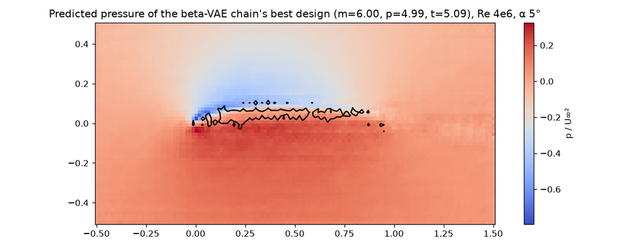

**The decoded field of the β-VAE chain's pick.** Usable for screening, not for inspection: the ragged outline shows that the decoded geometry is not a clean airfoil.

All three models agree on a region, not on a design: thin, strongly cambered, camber in the front half. Every pick has t = 5.09 %, the thinnest section in the data, and the camber changes with the model and with the seed. Inside the box the predicted C_L/C_D rises toward thinner airfoils, so the search stops where the training data end, which is exactly where the models disagree most and where nothing has been tested.

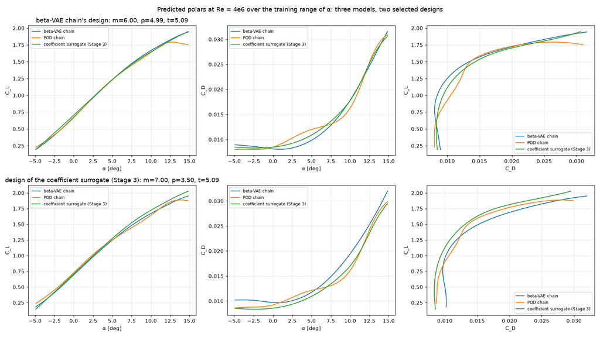

Distances in the standardised parameter space the surrogate sees. Both picks share the same nearest training case, a thicker section (t 6.10 %).

| Design | Distance to the nearest training case | Percentile among the 111 test cases |
| --- | --- | --- |
| β-VAE chain's pick | 0.730 (five parameters) | 42nd |
| Part 1 surrogate's pick | 0.805 (five parameters) | 60th |
| Part 1 surrogate's pick | 0.530 (shape only) | 96th |
| Test cases, median | 0.759 (five parameters) | — |

By distance, neither optimum is an extrapolation: each is as close to a training case as a typical test case. But both sit on the boundary of the data in thickness, where the models disagree on the best camber and nothing was tested. Distance alone does not expose a boundary; the disagreement does, which is what the next section measures.

## Results 4 — How far the search can be trusted

### An ensemble over the design space

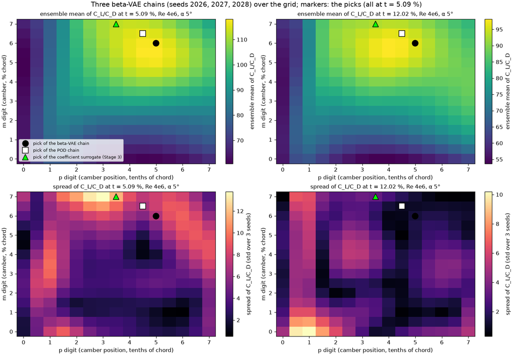

**Top: ensemble mean of C_L/C_D over camber and camber position** at the thinnest and at a mid thickness. **Bottom: the spread** over the three seeds of the chain. Markers: the picks of the three models.

The spread is largest exactly where the optima sit. The median spread over the 3,600 candidates is 2.58 in C_L/C_D; at the three picks it is 6.95, 6.75 and 11.69, that is 2.6 to 4.5 times the median, in the 94th to 99.9th percentile of the grid. The median spread falls from 4.55 at t = 5.1 % to 2.04 at t = 19.9 %.

The ensemble cannot rank the top of the grid: its best candidate (m 5.5, p 5.0, t 5.09; 118.1 ± 5.6) has 46 others within one standard deviation of it. On unseen cases the spread is a flag, not an error bar: over the 111 test cases the ensemble standard deviation of C_L and the error of the ensemble mean have a Spearman correlation of 0.29, and the 20 % of cases with the largest spread carry 1.5 times the error of the rest. Averaging the three chains also lowers the C_L RMSE from 0.0212 to 0.0152.

### What the eight coordinates encode

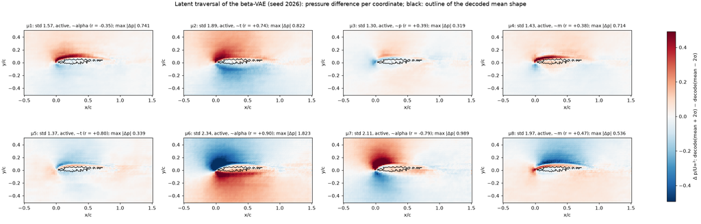

**Latent traversal.** Change of the decoded pressure field when one coordinate moves from −2σ to +2σ with the others at their mean; black: outline of the decoded mean shape. The α coordinates move the suction peak, the thickness coordinates make a symmetric change above and below the body.

Pearson correlation of each posterior mean with the five parameters over the 378 training fields.

| Coordinate | Follows most | r |
| --- | --- | --- |
| μ₆ / μ₇ | angle of attack α | +0.90 / −0.79 |
| μ₅ / μ₂ | thickness t | +0.80 / +0.74 |
| μ₈ / μ₄ | camber m | +0.47 / +0.38 |
| μ₃ / μ₁ | camber position p / α | +0.39 / −0.35 |
| any | log₁₀ Re | \|r\| ≤ 0.06 |

All eight coordinates are active (spread across training fields 1.3 to 2.3, posterior σ 0.06 to 0.08, KL term per coordinate 3.9 to 5.1), so the β warm-up did its job. They are not independent (|r| up to 0.64 between μ₄ and μ₈), which is what β = 10⁻³ buys: good reconstruction and a loosely organised latent space. No coordinate tracks the Reynolds number, whose effect on these fields is small.

### The cost of a query

| Query (CPU, three repeats after a warm-up) | Time | Per item |
| --- | --- | --- |
| β-VAE chain, 3,600 candidates → C_L, C_D | 0.101 s | 0.028 ms |
| β-VAE chain, one candidate → C_L, C_D | 45.8 ms | the fixed cost of two Keras calls |
| Decoder, one latent vector → full 5 × 64 × 128 field | 23.9 ms | — |
| Part 1 coefficient surrogate, 3,600 candidates | 0.056 s | 0.016 ms |
| Training: β-VAE 100 epochs / each latent surrogate | 73 s / 19–38 s | once |

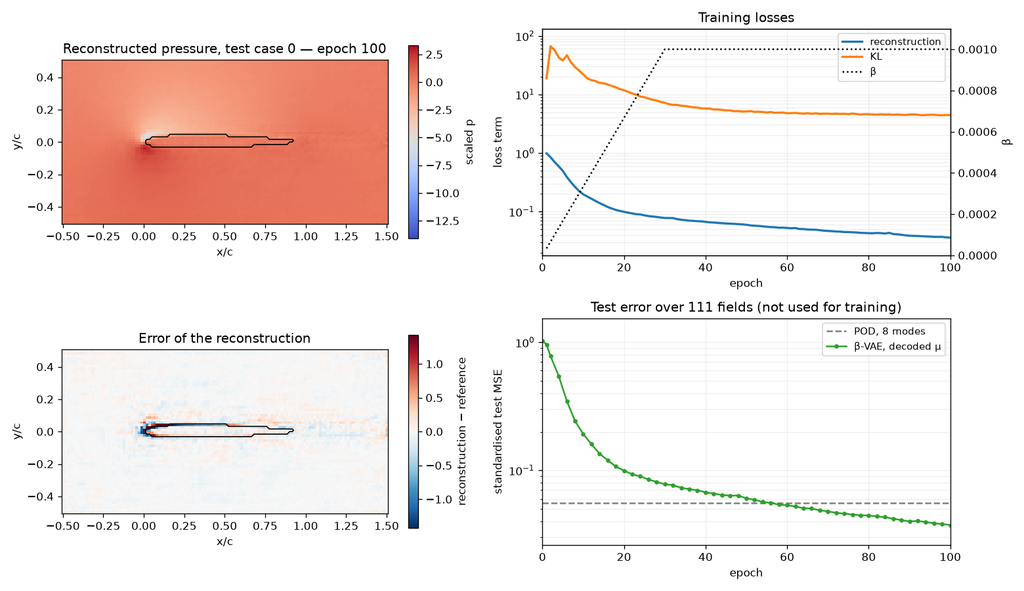

**Training behaviour.** Final frame of the training animation: reconstruction and error of one fixed test case, the two loss terms with β, and the test error against POD-8. The β-VAE passes POD at epoch 56 and is still improving at epoch 100; the KL term first rises while β is small (66.6 at epoch 2), falls to 7.2 as β reaches its maximum at epoch 30 and settles at 4.45.

## Results 5 — The field model inside the control loop (Stage 6)

Part 1 trained a flap controller in an environment whose steady lift and drag came from the coefficient surrogate. Stage 6 exchanges that one function for the β-VAE chain, with nothing else changed, and asks what changes in the control problem. The target lift is the zero-gust value of whichever function is in use: 0.7595 with the surrogate, 0.7483 with the chain. The chain runs as a NumPy forward pass that agrees with Keras to 3.6 × 10⁻⁷ and costs 0.014 ms per call against 0.011 ms for the surrogate, so the two routes cost the same per step.

[figure not shown]

**Only the teal box changes.** The Part 1 environment with its aerodynamic function exchanged; the lags, the gust, the observation, the action and the reward are the same.

[figure not shown]

**The training environment makes no visible difference; the test environment shifts every agent by a little.** Mean five-gust lift RMSE of three PPO agents per environment, dots the individual seeds, each agent tested in both environments.

The gap between training environments (at most 0.0002) is far smaller than the spread between seeds (up to 0.0018). The lower uncontrolled error in the chain environment follows from its smaller lift slope, 5.82 against 6.51 per radian.

| Trained in → tested in | Lift RMSE (3 seeds) |
| --- | --- |
| surrogate → surrogate | 0.0095 ± 0.0006 |
| surrogate → chain | 0.0106 ± 0.0004 |
| chain → surrogate | 0.0096 ± 0.0016 |
| chain → chain | 0.0104 ± 0.0018 |
| no control | 0.150 / 0.140 |

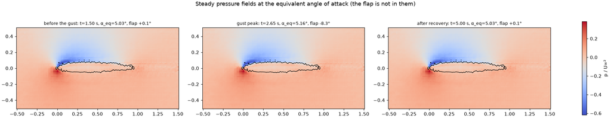

**The field along a flight.** Pressure decoded before the gust (1.5 s), at the gust peak (2.65 s) and after recovery (5.0 s) for a controlled flight through the fixed gust. The flap (−8.3° at the peak) is not in the field: the database has no flap, so this is the steady flow at the equivalent angle, and because the controller cancels most of the gust the field barely changes.

[figure not shown]

**What the chain does not add: range.** Lift at the controller's operating point from the three learned functions and thin-airfoil theory, swept beyond the training range of the angle (shaded). Inside it the learned functions differ by at most 0.05; at −10° they spread to 0.19, and at 18° they disagree by 0.14 with nothing in any of them to say which is right.

Exchanging the function left the controller unchanged within the seed spread, with the equivalent angle between 4.35° and 5.57° in every flight, deep inside the trusted range. That is the result one would hope for, and also the reason it is not a validation: both functions were fitted to the same 378 cases and agree where the agent flies. What the chain adds is the field; what it cannot add is range.

## Key observations

1. **Eight numbers are not many for these fields.** 33 POD modes hold 95 % of the variance; at eight coordinates the β-VAE cuts the test error by a third, but POD with 20 modes is better still. The nonlinear model pays off only because the downstream models need few coordinates.
2. **The compression, not the surrogate, limits accuracy.** A good latent predictor adds about 2 % to the field error; the linear fit adds 0.06 and the training mean 0.33 to 0.39. Improving the compression is the lever.
3. **Fields and forces from the same eight numbers.** The β-VAE chain reaches C_L RMSE 0.0212 and C_D RMSE 0.00074 on 111 unseen cases, on a par with a surrogate trained directly on the coefficients, and it can also return the field.
4. **The design search finds a corner, not a design.** All optima lie at the thinnest section in the data, the camber changes with model and seed, and the ensemble spread at the picks is 2.6 to 4.5 times the grid median. A solver run is the missing step.
5. **Distance to the data is not enough as a validity test.** Both picks are as close to a training case as a typical test case, yet they sit on the boundary in thickness. Seed and model disagreement exposed what distance did not.
6. **The latent space is readable.** All eight coordinates are active; two follow the angle of attack, two follow the thickness, none follows the Reynolds number, and the traversal panels show each one acting where the physics says it should.
7. **The field model works inside the control loop.** Controllers trained with it match those trained with the coefficient surrogate within the seed spread, at the same cost per step, and the field can be decoded along the flight.

## Conclusion

The same function carries the limits of its data. The design search ran into the edge of the training box, and the models disagree exactly there. That disagreement, measured with three seeds and an ensemble, turned out to be a more useful warning than the distance to the nearest training case. The workflow the two parts point to is: build the database once, search or control in the reduced space, and confirm the result with one solver run. The last step is the one not taken here.

Placed inside the Part 1 control environment, the field model did the job of the coefficient surrogate without a measurable change in the controller. Two pieces are missing before the field, and not only the coefficients, can respond to the control: a database with flap deflections as a sixth input, and a model that advances the latent state in time, which steady simulations cannot provide.

← Back to Part 1: a flap controller trained inside a CFD-built surrogate

## Code, data and reproducibility

The two notebooks of the repository; Stage 6 also needs the Part 1 surrogate files and the Part 1 PPO agent, which are included.

| Notebook | Stage |
| --- | --- |
| `05_airfrans_rom_betavae_design.ipynb` | Stage 5 — Reduced-order models of the flow fields and a latent-space design search |
| `06_field_model_in_control_loop.ipynb` | Stage 6 — The field model inside the flap-control loop |

[output not shown]